# ModelOfClusterFormation slides

## Why are (high-mass) star clusters important?

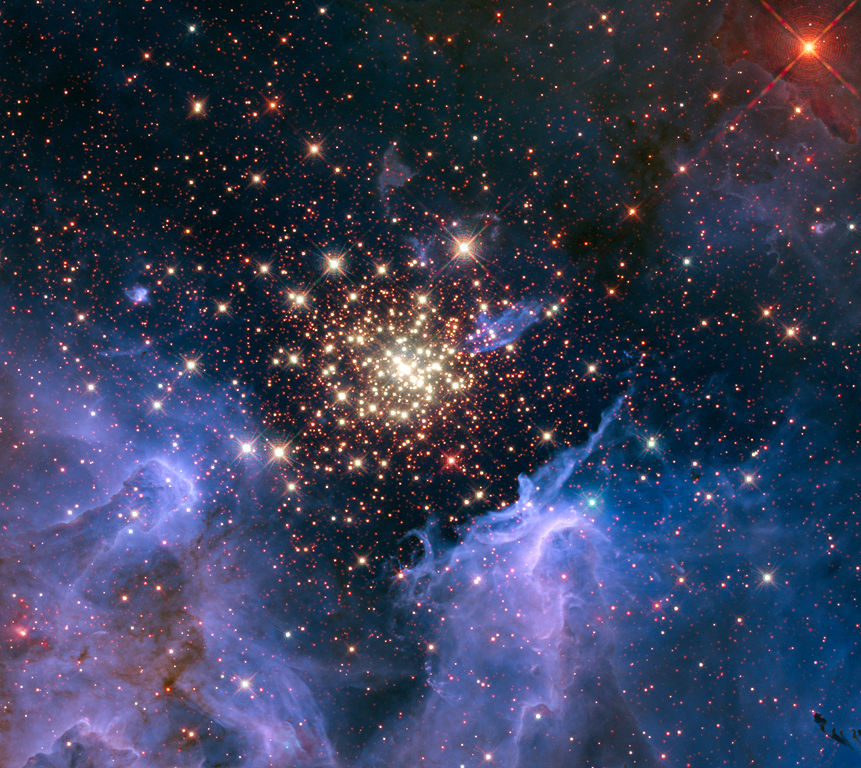

```python
Image('ngc3603.jpg',width="500px")
```

- Only locations in which a (probably coeval) IMF is fully sampled
- Most luminous sub-regions of a galaxy
  - visible as point or mildly resolved sources in nearby galaxies (& therefore countable!)
- Most massive gravitationally bound objects forming in the $z=0$ universe?
  - formation conditions may be representative of early universe
  - low-mass analogs to Globular clusters

## Setting up an experiment

Starless cores (e.g. B68) and starless clumps (IRDCs) are well-studied and common. The former are thought to be precursors to single stars, while the latter are likely to be precursors to open clusters.

Are there starless high-mass protoclusters, i.e. starless precursors to objects like NGC 3603, Westerlund 1, and The Arches? (these are known as "Young Massive Clusters" or YMCs)

New data - blind surveys of the Galactic plane - make this question approachable.

### What are the properties of a proto-YMC?

(this section could do with some references, but [Portegies-Zwart 2010](http://adsabs.harvard.edu/abs/2010ARA%26A..48..431P) contains most of the important details)

1. They are rare. Their population follows a power law with index 2, such that a $10^4 M_\odot$ cluster is 100 times less likely than a $10^3 M_\odot$ cluster. This is known from YMC studies in other galaxies (M83, M31).
2. They contain a lot of mass, by definition. They need *at least* as much mass in gas as they'll have in stars, but probably $3-30\times$ more than that.
3. They are compact. This is a tricky point: YMCs are observed to be very compact, with $r\sim1-5$ pc. It is not possible to form a massive cluster with $r\sim10$ pc and have it shrink to $r\sim5$ pc over the lifetime of the most massive stars, yet the massive stars are preferentially seen twoards the center. Therefore, the clumps that formed the massive stars must also form compact.
4. From #2 and #3 above, they must have high escape velocities. They can therefore have large linewidths and yet remain bound.

### What are the *observable* properties of a proto-YMC?

Assuming they go through a starless phase, they will have $>10^4 M_\odot$ within a radius $r<2.5$ pc.

Existing surveys, specifically the BGPS, ATLASGAL, and Hi-Gal, are complete to such objects throughout the Galactic plane.

# Computing Mass

In order to acquire a mass-limited sample, we need to know how an observed flux density translates to a gas mass for a given distance.

```python
print("Gas mass per Jansky of 1.1 mm flux at a distance of 1 kpc at 20K: ",
      dust.massofsnu(271.1*u.GHz, 1*u.Jy, (2*pi*(33*u.arcsec/2.35)**2), distance=1*u.kpc, temperature=20*u.K))
print("Gas mass per Jansky of 1.1 mm flux at a distance of 1 kpc at 10K: ",
      dust.massofsnu(271.1*u.GHz, 1*u.Jy, (2*pi*(33*u.arcsec/2.35)**2), distance=1*u.kpc, temperature=10*u.K))
print("The BGPS v1.0 fluxes had to be corrected by a factor of 1.5, plus another factor of 1.5 'aperture correction' for the 40 arcsec apertures.\n"
      "This will be used below.")
```

```
Gas mass per Jansky of 1.1 mm flux at a distance of 1 kpc at 20K:  13.1000565964 solMass
Gas mass per Jansky of 1.1 mm flux at a distance of 1 kpc at 10K:  38.2071736907 solMass
The BGPS v1.0 fluxes had to be corrected by a factor of 1.5, plus another factor of 1.5 'aperture correction' for the 40 arcsec apertures.
This will be used below.
```

With a direct translation from flux density to mass in hand, with $<5\times$ uncertainty due to temperature, the dominant remaining uncertainty is the distance.

## Distances

Given an assumed uniform rotation curve in our galaxy, a cloud's velocity is enough to give an upper limit on its distance.

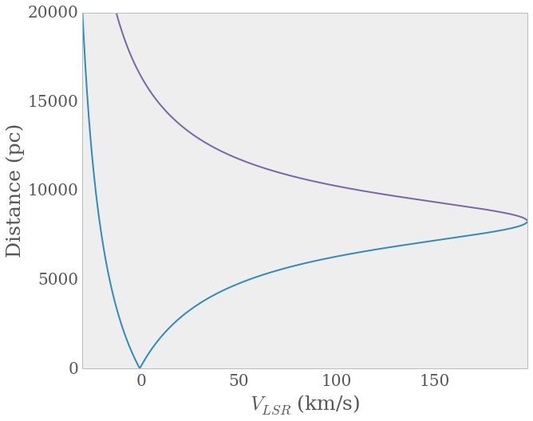

```python
figure(figsize=(10,8))
ax = gca()
plot(v,Dnear)
plot(v,Dfar)
ax.tick_params(axis='both', which='major', labelsize=20)
xlabel("$V_{LSR}$ (km/s)",fontsize=25)
ylabel("Distance (pc)",fontsize=25)
lims = axis([v.min(),v.max(),0,20e3],)
savefig("distance_vs_velocity_lon10.pdf",bbox_inches='tight')
```

For a given velocity, we have an upper limit on the distance.

We also have measurements of the velocities of all BGPS sources.

Using these maximum velocities, we can acquire a mass-limited sample, as long as we can later disambiguate which of the potentially massive sources are genuinely massive (and distant).

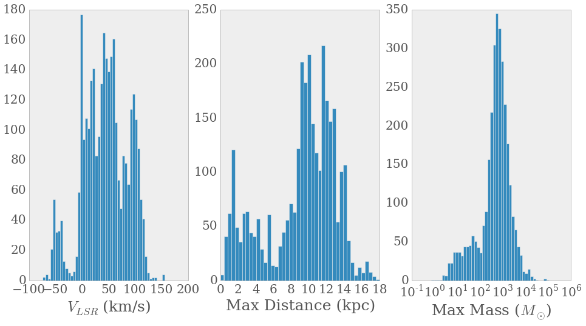

```python
figure(figsize=(16,8))
ax1 = subplot(1,3,1)
h,l,p = hist(v,bins=np.linspace(v.min(),v.max(),50))
ax2 = subplot(1,3,2)
h,l,p = hist(dmax/1e3,bins=np.linspace(0,20,50))
ax3 = subplot(1,3,3)
h,l,p = hist(mmax,bins=np.logspace(-0.25,5.5,50))
ax3.set_xscale('log')
for ax in ax1,ax2,ax3:
    ax.tick_params(axis='both', which='major', labelsize=20)
ax1.set_xlabel("$V_{LSR}$ (km/s)",fontsize=25)
ax2.set_xlabel("Max Distance (kpc)",fontsize=25)
ax3.set_xlabel("Max Mass ($M_{\odot}$)",fontsize=25)
savefig("velocity_maxdist_maxmass.pdf",bbox_inches='tight')
```

What is that excess at negative velocities? Is it anything interesting?

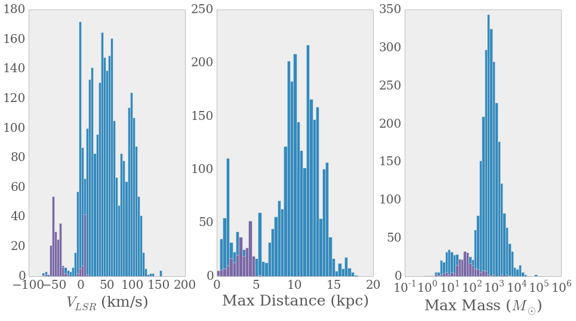

```python
figure(figsize=(16,8))
ax1 = subplot(1,3,1)
h,l,p = hist(v[lon<90],bins=np.linspace(v.min(),v.max(),50))
h,l,p = hist(v[lon>90],bins=np.linspace(v.min(),v.max(),50))
ax2 = subplot(1,3,2)
h,l,p = hist(dmax[lon<90]/1e3,bins=np.linspace(0,20,50))
h,l,p = hist(dmax[lon>90]/1e3,bins=np.linspace(0,20,50))
ax3 = subplot(1,3,3)
h,l,p = hist(mmax[lon<90],bins=np.logspace(-0.25,5.5,50))
h,l,p = hist(mmax[lon>90],bins=np.logspace(-0.25,5.5,50))
ax3.set_xscale('log')
for ax in ax1,ax2,ax3:
    ax.tick_params(axis='both', which='major', labelsize=20)
ax1.set_xlabel("$V_{LSR}$ (km/s)",fontsize=25)
ax2.set_xlabel("Max Distance (kpc)",fontsize=25)
ax3.set_xlabel("Max Mass ($M_{\odot}$)",fontsize=25)
savefig("velocity_maxdist_maxmass_innerouter.pdf",bbox_inches='tight')
```

Those negative velocities mostly come from low-mass clumps in the outer galaxy; they're nothing special.

## What volumes can we probe?

In order to measure a population of proto-clusters, we need to know what fraction of the Galaxy we're observing.

```python
# first, let's set our mass limit to be 10^4 and get a flux limit
fluxlimit = dust.snuofmass(271.1*u.GHz, 1e4*u.M_sun, (2*pi*(33*u.arcsec/2.35)**2), distance=25*u.kpc, temperature=20*u.K)
print("To see to the far side of the Galaxy, we need to be complete to ",fluxlimit)
```

```
To see to the far side of the Galaxy, we need to be complete to  1.22137071874 Jy
```

The BGPS is easily complete to this limit, but refer to the paper for other concerns (i.e., angular filtering).

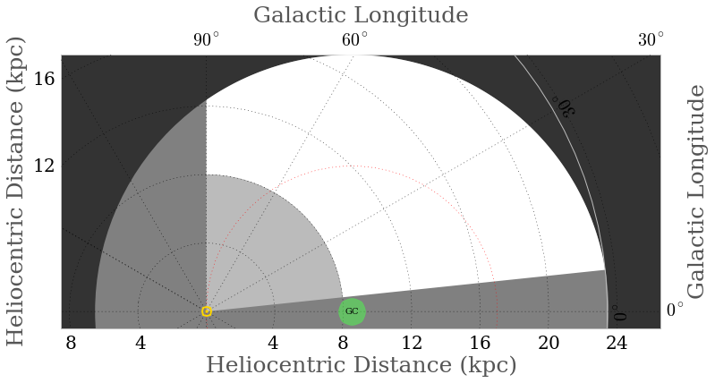

```python
import milkywayplots
mw = milkywayplots.MilkywayPlot(figure(figsize=(12,7)))
mw.do_everything(mindist=8, maxdist=26)
```

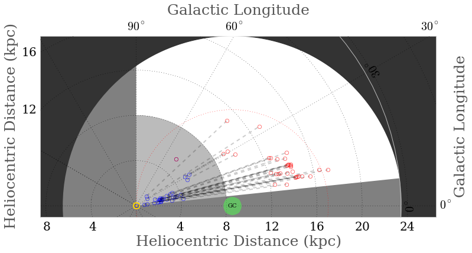

```python
mw = milkywayplots.MilkywayPlot(figure(figsize=(12,7)))
mw.do_everything(mindist=8, maxdist=26)
dmin = kdist.kdist(lon,lat,v,near=True,silent=True)
selection = mmax>1e4
mw.plot_londist(lon[selection], dmax[selection]/1e3, linestyle='none', marker='o', mfc='none', mec='r', zorder=105)
mw.plot_londist(lon[selection], dmin[selection]/1e3, linestyle='none', marker='o', mfc='none', mec='b', zorder=105)
mw.plot_londist([lon[selection]]*2, [dmin[selection]/1e3,dmax[selection]/1e3],
                linestyle='--', color='k', alpha=0.2, marker='', mfc='none', mec='r', zorder=105)
show()
```

These are all the BGPS massive proto-cluster candidates: all the sources that *could* have $M>10^4 M_\odot$.

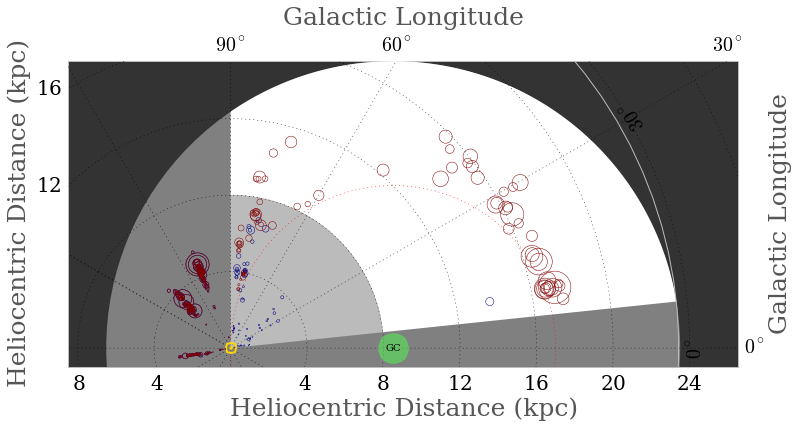

```python
mw = milkywayplots.MilkywayPlot(figure(figsize=(12,7)))
mw.do_everything(mindist=8, maxdist=26)
d,rgal = kdist.kdist(lon,lat,v,rrgal=True,silent=True)
selection = rgal/1e3 > 8.5
mmin = 14.01 * f40 * 2.25 * (dmin/1e3)**2
mw.scatter_londist(lon[selection], dmax[selection]/1e3, marker='o', color='maroon', edgecolors='maroon', facecolors='none', zorder=105, s=mmax[selection]/10)
mw.scatter_londist(lon[selection], dmin[selection]/1e3, marker='o', color='navy', edgecolors='navy', facecolors='none', zorder=105, s=mmin[selection]/10)
#mw.plot_londist([lon[selection]]*2, [dmin[selection]/1e3,dmax[selection]/1e3],
#                linestyle='--', color='k', alpha=0.2, marker='', mfc='none', mec='r', zorder=105)
show()
```

All of the objects outside the solar circle (maybe) are relatively low-mass; there is only one with $M>10^4 M_\odot$.

We now have a mass-limited sample of proto-YMCs and know where they are located. Can we model their locations, mass distribution, and lifetimes?

# A simple model of star cluster populations

-Where can they form?

-What is their mass function?

-How do they progress from gas to stars?

## Where do star clusters form?

Two simple models:

- Uniform disk:

$p(r) = 1$ if $r_1 < r < r_2$

$p(r) = 0$ otherwise

- Exponential disk:

$p(r) = r_1 e^{-r}$ for $r>r_1$

$p(r) = 0$ for $r<r_1$

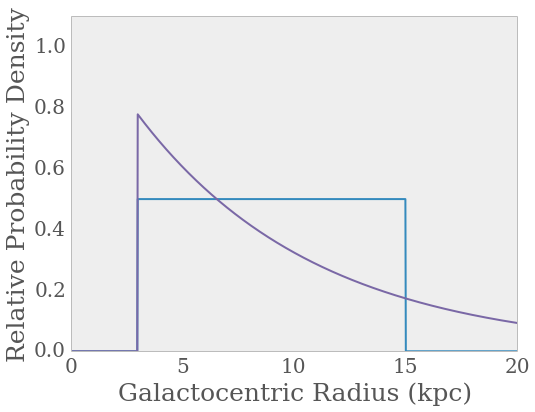

```python
figure(figsize=(8,6))
r = np.linspace(0,20,1000)
r_in = 3
r0 = 8.
p1 = ((r>r_in) * (r<15))/2.
p2 = (exp(-r/r0)/exp(-1/r0)*(r>r_in))
plot(r,p1,linewidth=2)
plot(r,p2,linewidth=2)
ylabel("Relative Probability Density")
xlabel("Galactocentric Radius (kpc)")
lims = axis([0,20,0,1.1])
```

Our sample is all within $r<8.5$ kpc.

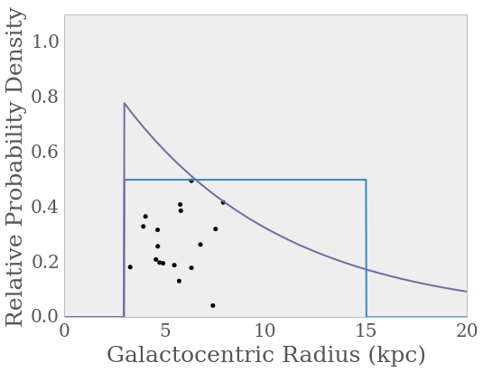

```python
figure(figsize=(8,6))
plot(r,p1,linewidth=2)
plot(r,p2,linewidth=2)
ylabel("Relative Probability Density")
xlabel("Galactocentric Radius (kpc)")
scatter(rsample/1e3, np.random.rand(rsample.size) * 0.5, color='k')
lims = axis([0,20,0,1.1])
```

## What is their mass function?

A Schecter function? Or a power-law?

The intrinsic mass function: $p(m) = A m^{-\beta} e^{-m/m_0}$ where $m_0$ is a "maximum mass" above which the number of clusters exponentially drops off

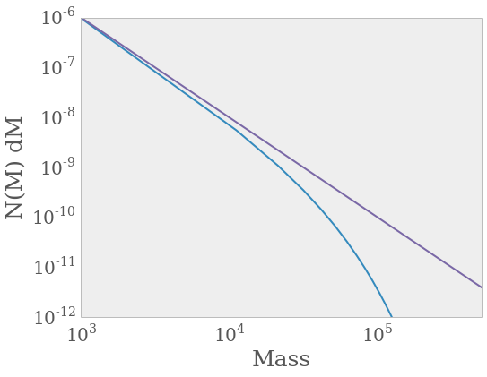

```python
figure(figsize=(8,6))
ax=gca()
ax.grid(False)
ax.tick_params(axis='both', which='major', labelsize=20)
result = loglog(m,p1,linewidth=2)
result = loglog(m,p2,linewidth=2)
axis([m.min(),m.max(),1e-12,1e-6])
xl = xlabel("Mass",fontsize=25)
yl = ylabel("N(M) dM",fontsize=25)
```

However, we only examined clusters in the range $m>10^4$

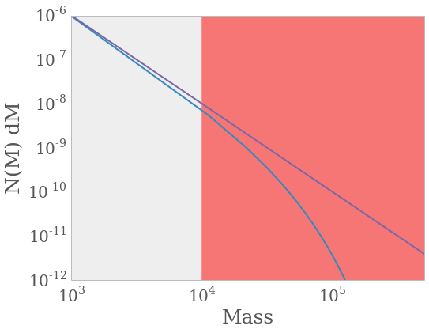

```python
figure(figsize=(8,6))
result = loglog(m,p1,linewidth=2)
result = loglog(m,p2,linewidth=2)
result = fill_between([1e4,5e5],[1e-12,1e-12],[1e-6,1e-6],color='r',alpha=0.5)
axis([m.min(),m.max(),1e-12,1e-6])
xl = xlabel("Mass")
yl = ylabel("N(M) dM")
```

Our sample provides very little constraint on the mass function.

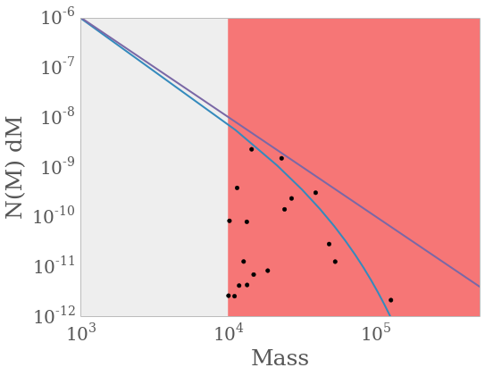

```python
figure(figsize=(8,6))
result = loglog(m,p1,linewidth=2)
result = loglog(m,p2,linewidth=2)
result = fill_between([1e4,5e5],[1e-12,1e-12],[1e-6,1e-6],color='r',alpha=0.5)
sample = T['massused'][T['massused'] > 1e4]
stars = 10**(np.random.rand(sample.size)*(np.log10(sample**-2)-np.log10(1e-12))+np.log10(1e-12))
scatter(sample,stars, color='k')
axis([m.min(),m.max(),1e-12,1e-6])
xl = xlabel("Mass")
yl = ylabel("N(M) dM")
```

## How do the massive clusters form?

- Either all their gas is in place at once
  - call this the "cloud collapse" model, an analog to prestellar cores
- Or it isn't
  - Some stars form, then others are accreted?
  - Or, some stars form, and *gas* is accreted
  - implies multiple generations
  - or "prolonged" star formation

Start with the first model: We can constrain it.

- First, clusters go through a "starless" phase
- Then, they form stars!
- Finally, the stars expel the gas

The starry, gas-rich phase lasts at least until the first supernova if $v_{esc} > C_{II}$ [(Bressert, Ginsburg et al 2012)](http://arxiv.org/abs/1208.3472) or until the gas is consumed

The first SN is at $t>3$ Myr. The gas consumption timescale may be shorted.

We measure an upper limit:

$N_{starless}(M>10^4) = 0$

$N_{starry}(M>10^4) = 3$ (conservatively) or $18$ (if you allow for 100% star formation efficiency)

The [Urquhart et al 2013](http://arxiv.org/abs/1302.2538) ATLASGAL sample extends this to ~6 in the conservative case.

- By selecting on masers, that sample may be biased
- Contreras and Longmore working on the unbiased sample?

So we "measure" $N_{starless}/N_{starry}$ = 0.

Poisson statistics: $\sigma_N = \frac{\sqrt{N_{starry}}}{N_{starry}} \approx 0.6$

Or, a $1-\sigma$ limit $N_{starless} < 0.6$

Lifetime of the starless phase:

$\frac{N_{starless}}{N_{starry}} = \frac{\tau_{starless}}{\tau_{starry}}$

Better statistics aren't warranted yet.

## What have we learned about the formation of massive clusters?

The proto-massive-cluster "clumps" of gas form massive stars rapidly *if* they exist at all.

It is possible that a single large clump never exists as a precursor to a high-mass cluster.

In this case, they must be assembled from smaller sub-clumps or larger, more extended clouds.

These are sometimes referred to as the "cloud collapse" model and "assembly line" models.

"The Brick", the ~$10^5 M_\odot$ cloud in the CMZ, may form a cluster by an entirely different mechanism. Then again, it may not form a cluster at all.

There is potentially some environmental dependence for massive cluster formation.